# Temporal data structures

Di Cook, Heike Hofmann  
1/31/2014

### Outline

- Seasonality: month, year
- Time indexes
- Differencing dates
- Week day, week end, day of the year
- Time zones

### Getting started

Birds affected by the BP Oil Spill as recorded by the [US Fish and Wildlife Service](http://gomex.erma.noaa.gov/erma.html)

```r
library(shapefiles)
birds.dbf<-read.dbf("../data/birds/birds.dbf")$dbf
dim(birds.dbf)
```

```
[1] 7229    8
```

```r
head(birds.dbf)
```

```
                 Species Latitude Longitude            Oiling Condition
1        Northern Gannet    30.33    -89.20 Not Visibly Oiled      Live
2          Laughing Gull    30.23    -88.32 Not Visibly Oiled      Live
3        Northern Gannet    30.27    -87.59     Visibly Oiled      Live
4 American White Pelican    29.30    -89.66 Not Visibly Oiled      Live
5          Brown Pelican    29.88    -88.88     Visibly Oiled      Live
6          Brown Pelican    29.00    -89.37 Not Visibly Oiled      Live
  BirdCount      Date_ Oil_Cond
1         1 2010-07-21        1
2         1 2010-05-05        1
3         1 2010-05-05        2
4         1 2010-05-05        1
5         1 2010-05-08        2
6         1 2010-05-14        1
```

### Checking the Date Variable

```r
library(lubridate)
is.Date(birds.dbf$Date_)
```

```
[1] TRUE
```

```r
colnames(birds.dbf)[7] <- "Date"
summary(birds.dbf$Date)
```

```
        Min.      1st Qu.       Median         Mean      3rd Qu.         Max.
"2010-05-05" "2010-07-11" "2010-08-03" "2010-07-30" "2010-08-22" "2010-10-17"
```

### Extracting Month

```r
birds.dbf$Month <- month(birds.dbf$Date)
table(birds.dbf$Month)
```

```
   5    6    7    8    9   10
 363  841 2252 2689 1049   35
```

```r
is.factor(birds.dbf$Month)
```

```
[1] FALSE
```

```r
birds.dbf$Month <- month(birds.dbf$Date, label=TRUE)
table(birds.dbf$Month)
```

```
 Jan  Feb  Mar  Apr  May  Jun  Jul  Aug  Sep  Oct  Nov  Dec
   0    0    0    0  363  841 2252 2689 1049   35    0    0
```

```r
is.factor(birds.dbf$Month)
```

```
[1] TRUE
```

### Days Since Spill

```r
birds.dbf$YDay <- yday(birds.dbf$Date)
head(birds.dbf$YDay)
```

```
[1] 202 125 125 125 128 134
```

```r
head(birds.dbf$Date)
```

```
[1] "2010-07-21" "2010-05-05" "2010-05-05" "2010-05-05" "2010-05-08"
[6] "2010-05-14"
```

```r
birds.dbf$Day<-mday(birds.dbf$Date)
head(birds.dbf$Day)
```

```
[1] 21  5  5  5  8 14
```

```r
birds.dbf$ASDay <- yday(birds.dbf$Date) - yday("2010-04-20")
head(birds.dbf$ASDay)
```

```
[1] 92 15 15 15 18 24
```

### Making summaries

Data comes as counts for each species, lots of different species. Aggregate the counts by day, using `table`, and get into elemental form

```r
library(ggplot2)
library(reshape)
birds.m <- melt(table(birds.dbf$ASDay,
        birds.dbf$Oiling))
colnames(birds.m)<-c("ASDay",
        "Oiling","count")
```

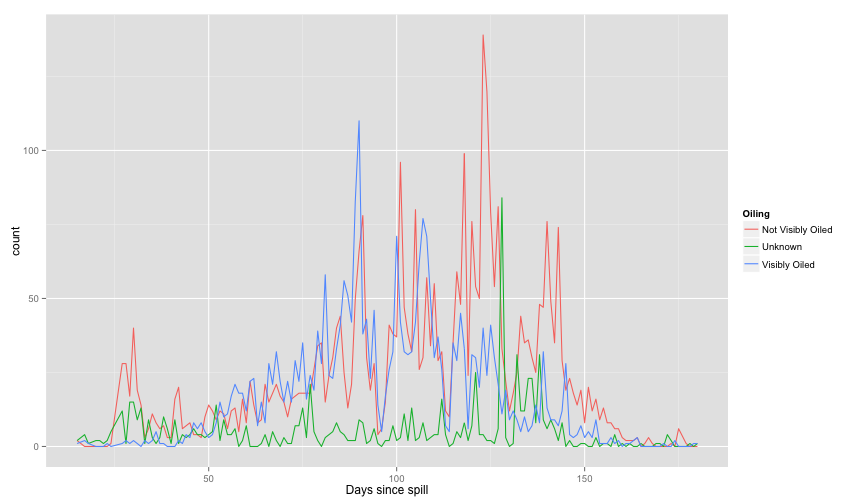

```r
qplot(ASDay, count,
  colour=Oiling, data=birds.m,
  geom="line", xlab="Days since spill")
```

### Aggregating at a lower resolution - weekly

```r
birds.dbf$Week <-
  week(birds.dbf$Date)
head(birds.dbf$Week)
```

```
[1] 29 18 18 18 19 20
```

```r
birds.dbf$ASWeek <-
  week(birds.dbf$Date) -
  week("2010-04-20")
head(birds.dbf$ASWeek)
```

```
[1] 13  2  2  2  3  4
```

```r
birds.m <- melt(table(birds.dbf$Week,
        birds.dbf$Oiling))
colnames(birds.m)<-c("ASWeek",
    "Oiling","count")
```

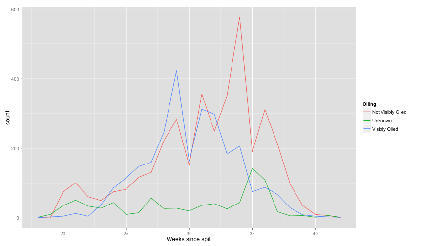

```r
qplot(ASWeek, count,
  colour=Oiling, data=birds.m,
  geom="line", xlab="Weeks since spill")
```

### Algebra with dates

```r
head(birds.dbf$Date)
```

```
[1] "2010-07-21" "2010-05-05" "2010-05-05" "2010-05-05" "2010-05-08"
[6] "2010-05-14"
```

```r
head(yday(birds.dbf$Date)/7+1)
```

```
[1] 29.86 18.86 18.86 18.86 19.29 20.14
```

```r
head(week(birds.dbf$Date))
```

```
[1] 29 18 18 18 19 20
```

```r
head(wday(birds.dbf$Date))
```

```
[1] 4 4 4 4 7 6
```

```r
wday("2014-01-01")
```

```
[1] 4
```

```r
wday(as.Date("2014-01-01")-years(1))
```

```
[1] 3
```

```r
wday(as.Date("2014-01-01")-years(10))
```

```
[1] 5
```

### Work day or weekend?

```r
birds.dbf$WDay <- wday(birds.dbf$Date)
head(birds.dbf$WDay)
```

```
[1] 4 4 4 4 7 6
```

```r
birds.dbf$WDay <- wday(birds.dbf$Date, label=TRUE)
head(birds.dbf$WDay)
```

```
[1] Wed Wed Wed Wed Sat Fri
Levels: Sun < Mon < Tues < Wed < Thurs < Fri < Sat
```

```r
birds.dbf$Weekend <- ifelse(birds.dbf$WDay=="Sat"|
    birds.dbf$WDay=="Sun", TRUE, FALSE)
table(birds.dbf$Weekend)
```

```
FALSE  TRUE
 5241  1988
```

### Check for Weekend collection difference

```r
birds.june <- subset(birds.dbf,
                Month=="Jun")
table(birds.june$WDay)
```

```
  Sun   Mon  Tues   Wed Thurs   Fri   Sat
  143   112   122   130    91   125   118
```

```r
table(birds.june$Weekend)
```

```
FALSE  TRUE
  580   261
```

```r
xm<-data.frame(table(birds.june$WDay))
colnames(xm)[1] <- "WeekDay"
```

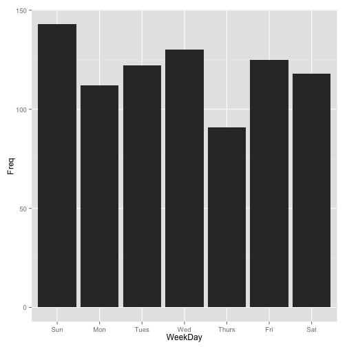

```r
qplot(WeekDay, Freq,
  data=xm, geom="bar")
```

### Quick quiz

What do these do?

`today()`, `now()`, `week(now())`

`week(now() - years(1))`

`week(now() - years(10))`

### Reading different date formats

Source: http://www.eoddata.com/

```r
Apple <- read.csv("../data/AAPL_20130101_20140130.csv")
head(Apple)
```

```
  Stock        Date  Open  High   Low Close   Volume
1  AAPL 01-Jan-2013 532.2 532.2 532.2 532.2        0
2  AAPL 02-Jan-2013 553.8 555.0 541.6 549.0 20017800
3  AAPL 03-Jan-2013 547.6 549.7 541.0 542.1 12605800
4  AAPL 04-Jan-2013 537.0 538.6 525.8 527.0 21225900
5  AAPL 07-Jan-2013 522.0 529.3 515.2 523.9 17291100
6  AAPL 08-Jan-2013 529.2 531.9 521.2 525.3 16382300
```

```r
is.Date(Apple$Date)
```

```
[1] FALSE
```

```r
Apple$Date <- as.Date(Apple$Date, format="%d-%b-%Y")
summary(Apple$Date)
```

```
        Min.      1st Qu.       Median         Mean      3rd Qu.         Max.
"2013-01-01" "2013-04-09" "2013-07-17" "2013-07-17" "2013-10-23" "2014-01-30"
```

### Reading different date formats

| Format | Date |
| --- | --- |
| %d-%m-%Y | 01-01-2014 |
| %d-%b-%Y | 01-Jan-2014 |
| %d-%b-%y | 01-Jan-14 |

### Quarterly reports

```r
Apple$quarter <- factor(quarter(Apple$Date, with_year = TRUE))
head(Apple$quarter)
```

```
[1] 2013.1 2013.1 2013.1 2013.1 2013.1 2013.1
Levels: 2013.1 2013.2 2013.3 2013.4 2014.1
```

```r
library(plyr)
Apple.qsum <- ddply(Apple, "quarter", summarise,
                    Low=min(Low, na.rm=T),
                    High=max(High, na.rm=T))
Apple.qsum
```

```
  quarter   Low  High
1  2013.1 419.0 555.0
2  2013.2 385.1 465.8
3  2013.3 401.2 513.7
4  2013.4 478.3 575.1
5  2014.1 496.7 561.0
```

### Time zones

Workhorse underlying lubridate is `as.POSIXlt()`

```r
as.POSIXlt(Sys.time(), "America/Chicago")
```

```
[1] "2014-01-31 14:45:49 CST"
```

```r
as.POSIXlt(Sys.time(), "Australia/Darwin")
```

```
[1] "2014-02-01 06:15:49 CST"
```

Why are both listed at “CST”? What is the time zone for Sydney?

### Time zones

Airline data from [Data Expo 2009](http://stat-computing.org/dataexpo/2009/)

```r
airlines <- read.csv("../data/airlines.1996.DFW.SEA.csv", row.names=1)
dim(airlines)
```

```
[1] 7484   29
```

```r
airlines[7484,]
```

```
        Year Month DayofMonth DayOfWeek DepTime CRSDepTime ArrTime CRSArrTime
5141286 1996    12         31         2      58         55     628        615
        UniqueCarrier FlightNum TailNum ActualElapsedTime CRSElapsedTime
5141286            DL      1446  N608DA               210            200
        AirTime ArrDelay DepDelay Origin Dest Distance TaxiIn TaxiOut Cancelled
5141286     190       13        3    SEA  DFW     1660      7      13         0
        CancellationCode Diverted CarrierDelay WeatherDelay NASDelay
5141286               NA        0           NA           NA       NA
        SecurityDelay LateAircraftDelay
5141286            NA                NA
```

### Time zones

```r
timedif <- airlines$CRSArrTime-airlines$CRSDepTime
summary(timedif)
```

```
   Min. 1st Qu.  Median    Mean 3rd Qu.    Max.
  -2200     201     257     283     581     599
```

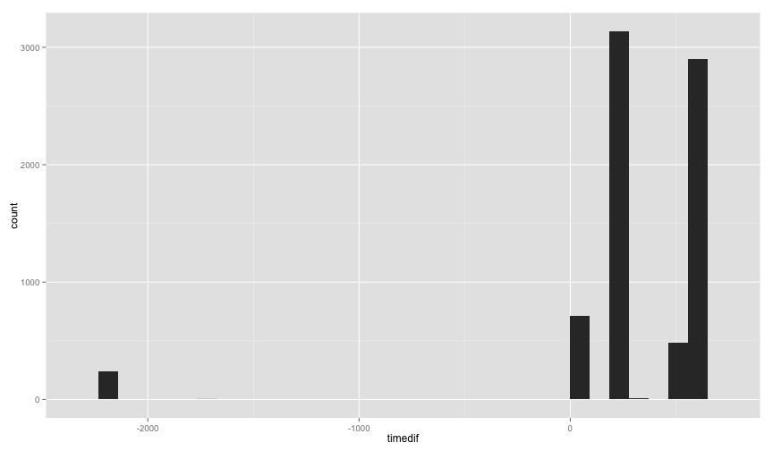

```r
qplot(timedif, geom="histogram")
```

### Time zones

Flight originated in Seattle, destined for Dallas

```r
airlines$CRSDepTime[7484]
```

```
[1] 55
```

```r
airlines$CRSArrTime[7484]
```

```
[1] 615
```

```r
airlines$CRSElapsedTime[7484]
```

```
[1] 200
```

```r
airlines$AirTime[7484]
```

```
[1] 190
```

### Time zones

Converting arrival time to a date variable

```r
arr <- parse_date_time(paste(airlines$Year[7484],
              airlines$Month[7484],
              airlines$DayofMonth[7484],
              airlines$CRSArrTime[7484]%/%100,
              airlines$CRSArrTime[7484]%%100),
        "%Y %m %d %H %M", truncated=5, tz="CST5CDT")
arr
```

```
[1] "1996-12-31 06:15:00 CST"
```

```r
dep <- parse_date_time(paste(airlines$Year[7484],
                      airlines$Month[7484],
                      airlines$DayofMonth[7484],
                      airlines$CRSDepTime[7484]%/%100,
                      airlines$CRSDepTime[7484]%%100),
                "%Y %m %d %H %M", truncated=5, tz="PST5PDT")
dep
```

```
[1] "1996-12-31 00:55:00 PST"
```

```r
arr-dep
```

[output not shown]

Why is this different from `CRSElapsedTime=200`?

### Reading

“Statistical Analyses and Reproducible Research”, Robert Gentleman and Duncan Temple Lang, 2004 (pdf on blackboard), some questions to initiate discussion:

- What is a compendium?
- How was David Donoho involved in reproducible research?
- What is literate programming?
- What components are necessary to produce a compendium?
- Give an example of transformation software.